# Homework 9 - Ridge and Lasso

Author

Affiliation

Akash Agrawal Bejarano, Ama K. Appau, Johnson Odejide, Josh Hall

American University

Published

November 6, 2023

## 01. Problem Definition

Becoming a billionaire is what many people look forward to, but what does it take to become one, are there specific things to do, or qualities to possess. Are billionaires self made or did they inherit their wealth? What can make a person’s net worth improve in a way that one can rank among these billionaires, are there things to watch out for?

These are the curiosities we have about this work that we seek an answer to as we explore the predictability of a billionaire as to whether they are self made or they inherited their wealth, as well as what the significant predictors are for the net worth of a billionaire.

## 02. Data Collection

Data Source - https://www.kaggle.com/datasets/nelgiriyewithana/billionaires-statistics-dataset?select=Billionaires+Statistics+Dataset.csv

Data Description:

- **rank**: The ranking of the billionaire in terms of wealth.
- **finalWorth**: The final net worth of the billionaire in U.S. dollars.
- **category**: The category or industry in which the billionaire’s business operates.Instal
- **personName**: The full name of the billionaire.
- **age**: The age of the billionaire.
- **country**: The country in which the billionaire resides.
- **city**: The city in which the billionaire resides.
- **source**: The source of the billionaire’s wealth.
- **industries**: The industries associated with the billionaire’s business interests.
- **countryOfCitizenship**: The country of citizenship of the billionaire.
- **organization**: The name of the organization or company associated with the billionaire.
- **selfMade**: Indicates whether the billionaire is self-made (True/False).
- **status**: “D” represents self-made billionaires (Founders/Entrepreneurs) and “U” indicates inherited or unearned wealth.
- **gender**: The gender of the billionaire.
- **birthDate**: The birthdate of the billionaire.
- **lastName**: The last name of the billionaire.
- **firstName**: The first name of the billionaire.
- **title**: The title or honorific of the billionaire.
- **date**: The date of data collection.
- **state**: The state in which the billionaire resides.
- **residenceStateRegion**: The region or state of residence of the billionaire.
- **birthYear**: The birth year of the billionaire.
- **birthMonth**: The birth month of the billionaire.
- **birthDay**: The birth day of the billionaire.
- **cpi_country**: Consumer Price Index (CPI) for the billionaire’s country.
- **cpi_change_country**: CPI change for the billionaire’s country.
- **gdp_country**: Gross Domestic Product (GDP) for the billionaire’s country.
- **gross_tertiary_education_enrollment**: Enrollment in tertiary education in the billionaire’s country.
- **gross_primary_education_enrollment_country**: Enrollment in primary education in the billionaire’s country.
- **life_expectancy_country**: Life expectancy in the billionaire’s country.
- **tax_revenue_country_country**: Tax revenue in the billionaire’s country.
- **total_tax_rate_country**: Total tax rate in the billionaire’s country.
- **population_country**: Population of the billionaire’s country.
- **latitude_country**: Latitude coordinate of the billionaire’s country.
- **longitude_country**: Longitude coordinate of the billionaire’s country.

Load the required libraries

```r
library(tidyverse)
library(tidymodels)
# library(recipeselectors)
library(dplyr)
library(ggplot2)
library(leaps)
library(glmnet)
library(corrplot)
```

Load the data

```r
data <- read_csv("Billionaires.csv")
nrow(data)
```

```
[1] 2640
```

```r
ncol(data)
```

```
[1] 35
```

```r
# head(data)
# dim(data)
glimpse(data)
```

```
Rows: 2,640
Columns: 35
$ rank                                       <dbl> 1, 2, 3, 4, 5, 6, 7, 8, 9, …
$ finalWorth                                 <dbl> 211000, 180000, 114000, 107…
$ category                                   <chr> "Fashion & Retail", "Automo…
$ personName                                 <chr> "Bernard Arnault & family",…
$ age                                        <dbl> 74, 51, 59, 78, 92, 67, 81,…
$ country                                    <chr> "France", "United States", …
$ city                                       <chr> "Paris", "Austin", "Medina"…
$ source                                     <chr> "LVMH", "Tesla, SpaceX", "A…
$ industries                                 <chr> "Fashion & Retail", "Automo…
$ countryOfCitizenship                       <chr> "France", "United States", …
$ organization                               <chr> "LVMH Moët Hennessy Louis V…
$ selfMade                                   <lgl> FALSE, TRUE, TRUE, TRUE, TR…
$ status                                     <chr> "U", "D", "D", "U", "D", "D…
```

[output cut: 22 more lines]

```r
dim(data)
```

```
[1] 2640   35
```

The data contains 2640 observations of 35 features (variables)

## 03. Exploratory Data Analysis

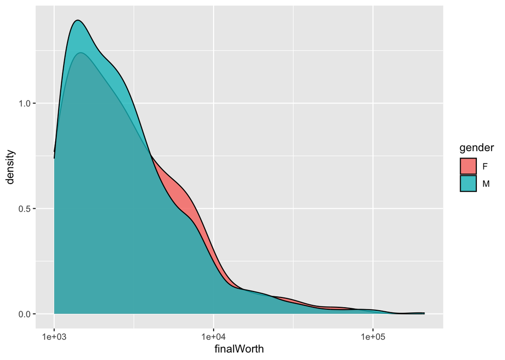

```r
# Comparing male and female final worth
data |>
  ggplot(aes(finalWorth, fill = gender)) +
  geom_density(alpha = 0.8) +
  scale_x_log10()
```

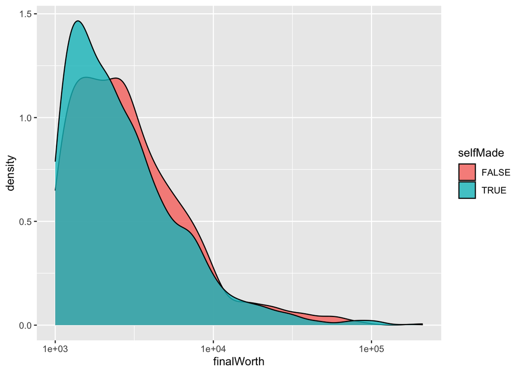

```r
# Comparing selfmade billionaires
data |>
  ggplot(aes(finalWorth, fill = selfMade)) +
  geom_density(alpha = 0.8) +
  scale_x_log10()
```

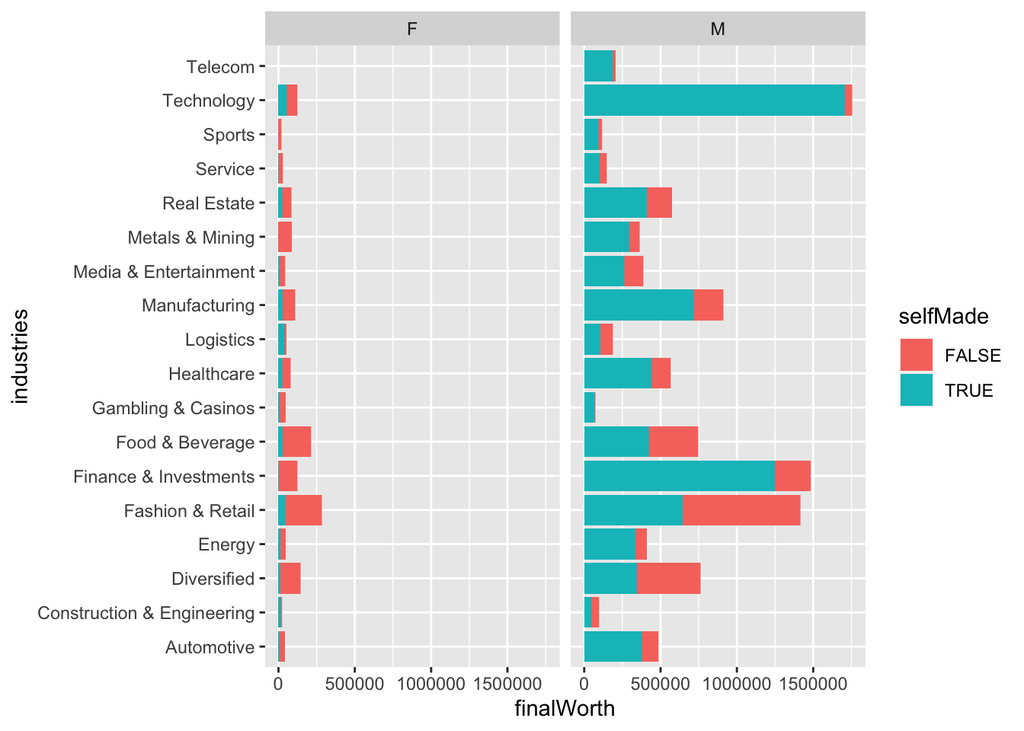

```r
data |>
  ggplot(aes(x = industries, finalWorth)) +
  geom_histogram(aes(fill = selfMade), stat = "identity") +
  coord_flip() +
  facet_wrap(~ gender)
```

## 04. Data cleaning

We removed the columns with a lot of NAs and the ones which we wont use. For instance, latitude and longitude

```r
data <- mutate(data, age = na_if(age, -1))
data <- data[-c(4,6:11,13,15:24,26,28,29,31,34,35)]

colSums(is.na(data))
```

```
                   rank              finalWorth                category
                      0                       0                       0
                    age                selfMade                  gender
                     65                       0                       0
            cpi_country             gdp_country life_expectancy_country
                    184                     164                     182
 total_tax_rate_country      population_country
                    182                     164
```

```r
cleaned_data <- na.omit(data)
dim(cleaned_data)
```

```
[1] 2407   11
```

```r
colSums(is.na(cleaned_data))
```

```
                   rank              finalWorth                category
                      0                       0                       0
                    age                selfMade                  gender
                      0                       0                       0
            cpi_country             gdp_country life_expectancy_country
                      0                       0                       0
 total_tax_rate_country      population_country
                      0                       0
```

```r
Classbill <-
  cleaned_data |>
  relocate(selfMade,.before = rank)

Classbill$gdp_country = as.numeric(gsub("[\\$,]", "", Classbill$gdp_country))
```

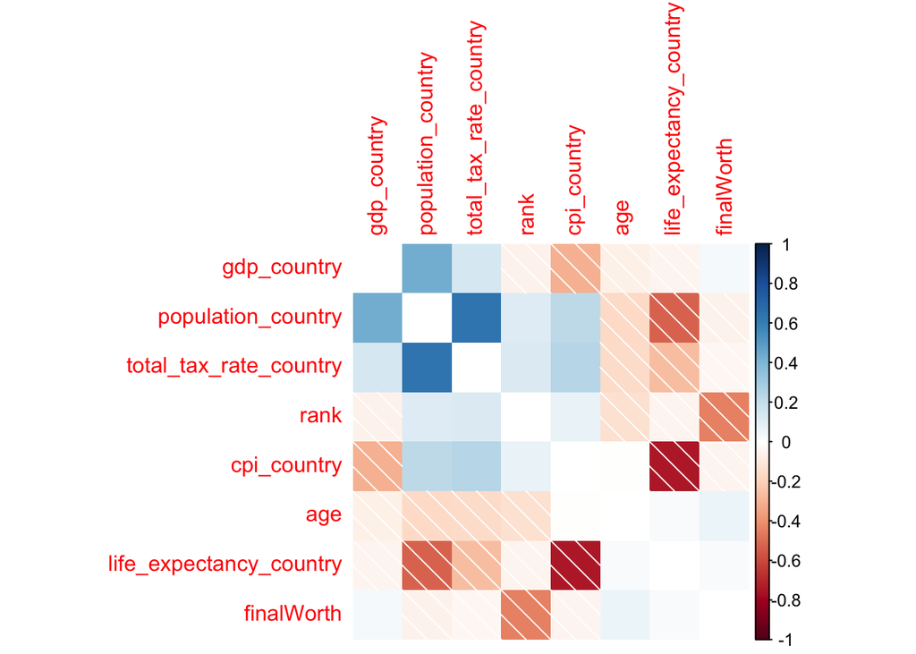

```r
numeric_data <- select_if(Classbill, is.numeric)
cor_bill <- cor(numeric_data)
# corrplot(cor_bill, method = 'number')
corrplot(cor_bill, method = 'shade', order = 'AOE', diag = F)
```

## 05. Classification Models

### Logistic Regression

```r
set.seed(123)
training <- .70
s <- sample(nrow(Classbill), floor(training*nrow(Classbill)))
Ttrain<-Classbill[s,]
Ttest<-Classbill[-s,]

a <-  glm(as.factor(selfMade) ~ ., family = "binomial", data = Ttrain)

Testp<- predict(a, type = "response",  newdata = Ttest)

threshold <- seq(0, 1, .01)
TPR <-  FPR <- err.rate <- rep(0, length(threshold))


for (i in seq_along(threshold)) {
Yhat <- rep(NA_character_, nrow(Ttest))
Yhat <-  ifelse(Testp >= threshold[[i]], "TRUE", "FALSE")

err.rate[i] <- mean(Yhat != Ttest$selfMade)
TPR[[i]] <- sum(Yhat == "TRUE" & Ttest$selfMade == "FALSE")/
  sum(Ttest$selfMade == "TRUE")
FPR[[i]] <- sum(Yhat == "TRUE" & Ttest$selfMade == "FALSE")/
  sum(Ttest$selfMade == "FALSE")
}

table(Ttest$selfMade)
```

```
FALSE  TRUE
  232   491
```

```r
min(err.rate)
```

```
[1] 0.2323651
```

```r
threshold[which.min(err.rate)]
```

```
[1] 0.47
```

```r
logErrorRate <- min(err.rate)
summary(a)
```

```
Call:
glm(formula = as.factor(selfMade) ~ ., family = "binomial", data = Ttrain)

Coefficients:
                                     Estimate Std. Error z value Pr(>|z|)
(Intercept)                        -8.034e+00  2.661e+00  -3.019 0.002533 **
rank                                1.546e-04  9.448e-05   1.637 0.101651
finalWorth                         -2.209e-06  5.814e-06  -0.380 0.704034
categoryConstruction & Engineering  1.178e+00  5.372e-01   2.193 0.028274 *
categoryDiversified                 3.205e-01  3.819e-01   0.839 0.401348
categoryEnergy                      1.181e+00  4.472e-01   2.641 0.008269 **
categoryFashion & Retail            6.758e-01  3.654e-01   1.850 0.064385 .
categoryFinance & Investments       1.420e+00  3.657e-01   3.884 0.000103 ***
categoryFood & Beverage             3.112e-01  3.744e-01   0.831 0.405951
categoryGambling & Casinos          1.562e+00  6.779e-01   2.305 0.021185 *
categoryHealthcare                  1.243e+00  3.929e-01   3.164 0.001556 **
categoryLogistics                   1.690e+00  6.417e-01   2.633 0.008459 **
categoryManufacturing               9.820e-01  3.656e-01   2.686 0.007229 **
categoryMedia & Entertainment       1.170e+00  4.641e-01   2.521 0.011690 *
categoryMetals & Mining             1.915e+00  4.869e-01   3.933 8.40e-05 ***
categoryReal Estate                 9.216e-01  3.919e-01   2.352 0.018681 *
categoryService                     3.417e-01  4.891e-01   0.699 0.484776
categorySports                      1.013e+00  5.972e-01   1.696 0.089884 .
categoryTechnology                  2.696e+00  4.355e-01   6.190 6.01e-10 ***
categoryTelecom                     2.236e+00  7.055e-01   3.169 0.001529 **
age                                -1.875e-03  4.996e-03  -0.375 0.707507
genderM                             2.123e+00  1.919e-01  11.064  < 2e-16 ***
cpi_country                         4.520e-03  3.692e-03   1.224 0.220866
gdp_country                         4.377e-14  8.583e-15   5.099 3.41e-07 ***
life_expectancy_country             6.104e-02  2.848e-02   2.143 0.032088 *
total_tax_rate_country             -5.390e-03  6.452e-03  -0.835 0.403499
population_country                  8.919e-10  2.073e-10   4.302 1.69e-05 ***
---
Signif. codes:  0 '***' 0.001 '**' 0.01 '*' 0.05 '.' 0.1 ' ' 1

(Dispersion parameter for binomial family taken to be 1)

    Null deviance: 2016.5  on 1683  degrees of freedom
Residual deviance: 1612.2  on 1657  degrees of freedom
AIC: 1666.2

Number of Fisher Scoring iterations: 5
```

### KNN Classification

```r
#removing the categorical predictors category and gender
Classbill1 = Classbill[-c(4,6)]
library(class)
set.seed(123)
training <- .70
s<- sample(nrow(Classbill1), floor(training*nrow(Classbill1)))

Xtraining<-Classbill1[s,2:9]
Ytraining<- Classbill1$selfMade[s]
Xtesting <- Classbill1[-s,2:9]
Ytesting <- Classbill1$selfMade[-s]

z <- rep(1:50)
x <- rep(1:50)
c <- rep(1:50)

for (k in 1:50){
  D <- knn(Xtraining, Xtesting, Ytraining, k = k)
  z[k] <- mean(D != Ytesting)
  x[k] <- sum(D == 1 & Ytesting == 1) / sum(Ytesting == 1)
  c[k] <- sum(D == 1 & Ytesting == 0) / sum(Ytesting == 0)
}

paste("The k which minimizes the prediction error rate is",which.min(z))
```

```
[1] "The k which minimizes the prediction error rate is 14"
```

```r
paste("The associated error rate is", z[which.min(z)])
```

```
[1] "The associated error rate is 0.301521438450899"
```

```r
KNNErrorRate <- z[which.min(z)]
```

```r
set.seed(123)
training <- .70
D <- knn(Xtraining, Xtesting, Ytraining, k = 14)
table(Ytesting,D)
```

```
        D
Ytesting FALSE TRUE
   FALSE    70  162
   TRUE     59  432
```

```r
cr = (table(Ytesting, D)[1, 1] + table(Ytesting, D)[2, 2])/(0.3*nrow(Classbill1))
paste("The classification rate is", cr)
```

```
[1] "The classification rate is 0.695194571389004"
```

### Classification Tree

```r
library(tree)
Classbill1 =Classbill[-c(4,6)]
Classbill1$selfMade <- as.factor(Classbill1$selfMade)
set.seed(123)
training <- .70
s<- sample(nrow(Classbill1), floor(training*nrow(Classbill1)))
trainingdat <- Classbill1[s,]
testingdat <- Classbill1[-s,]
tree <- tree(selfMade ~. , data = trainingdat)
summary(tree)
```

```
Classification tree:
tree(formula = selfMade ~ ., data = trainingdat)
Variables actually used in tree construction:
[1] "population_country"     "total_tax_rate_country"
Number of terminal nodes:  4
Residual mean deviance:  1.024 = 1720 / 1680
Misclassification error rate: 0.2607 = 439 / 1684
```

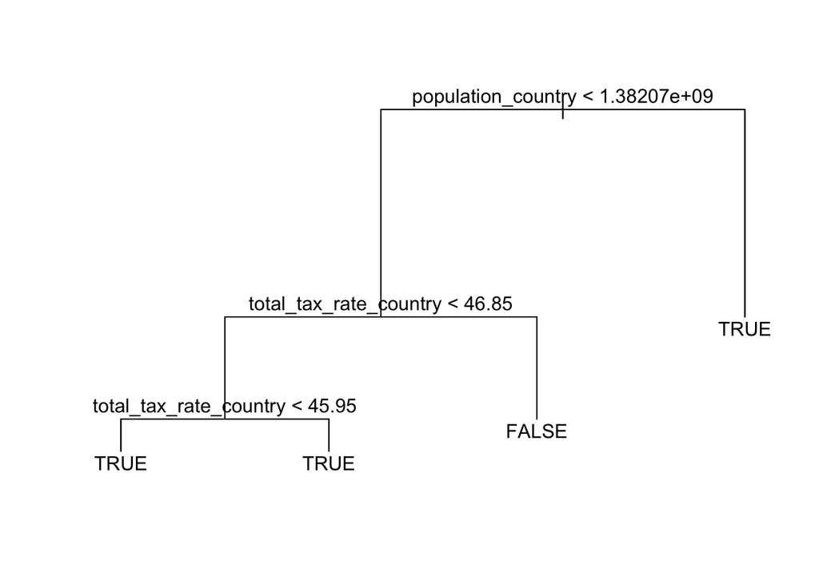

```r
plot(tree)
text(tree)
```

```r
yhat = predict(tree, newdata = testingdat, type = "class")
table(yhat, testingdat$selfMade)
```

```
yhat    FALSE TRUE
  FALSE    82   74
  TRUE    150  417
```

```r
cv <- cv.tree(tree, FUN = prune.misclass)
cv
```

```
$size
[1] 4 3 1

$dev
[1] 442 442 480

$k
[1] -Inf  0.0 21.5

$method
[1] "misclass"

attr(,"class")
[1] "prune"         "tree.sequence"
```

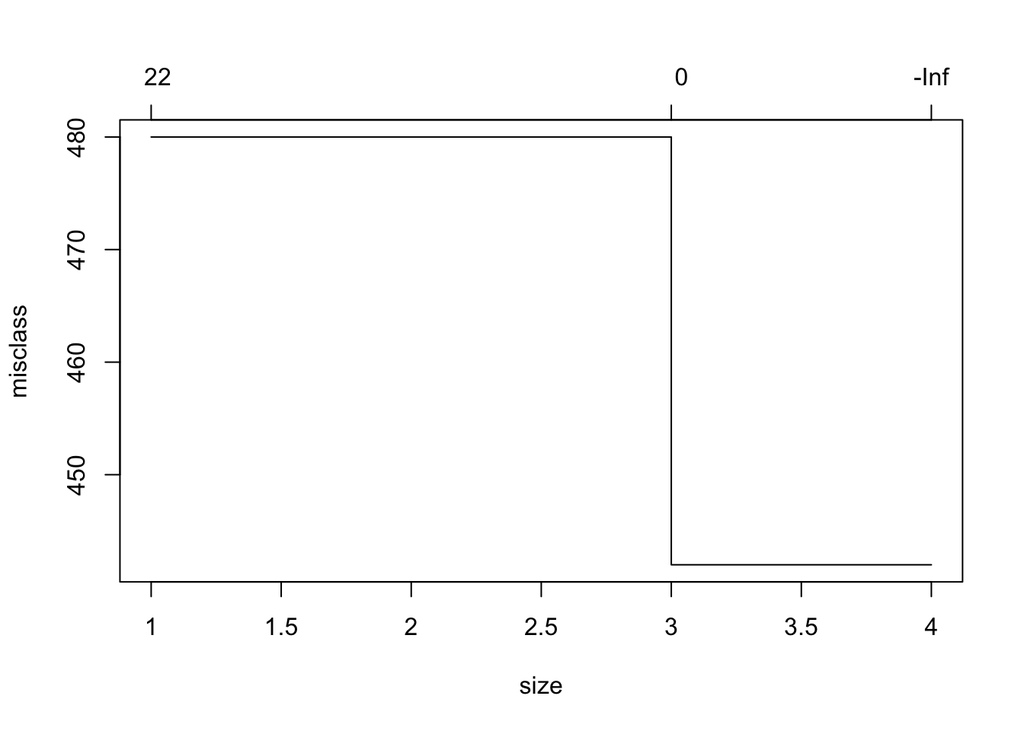

```r
plot(cv)
```

```r
trp <- prune.misclass(tree, best = 3)
summary(trp)
```

```
Classification tree:
snip.tree(tree = tree, nodes = 4L)
Variables actually used in tree construction:
[1] "population_country"     "total_tax_rate_country"
Number of terminal nodes:  3
Residual mean deviance:  1.04 = 1748 / 1681
Misclassification error rate: 0.2607 = 439 / 1684
```

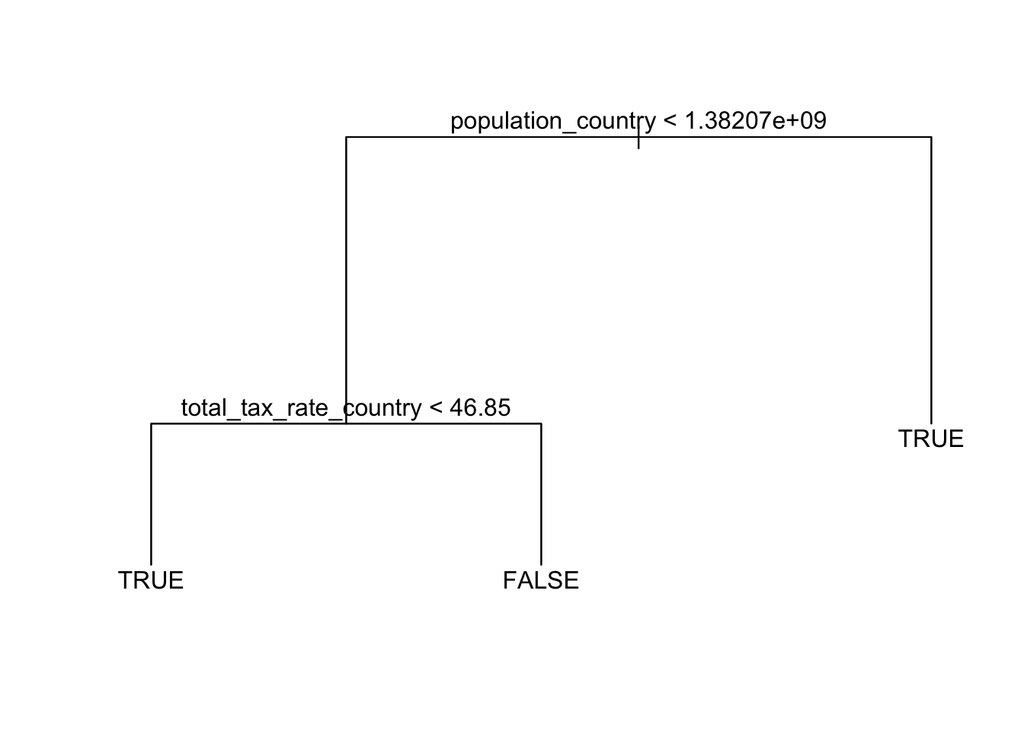

```r
plot(trp)
text(trp)
```

```r
#training error rate
summary(tree)$misclass[1]/summary(tree)$misclass[2] # Original
```

```
[1] 0.2606888
```

```r
summary(trp)$misclass[1]/summary(trp)$misclass[2] # Pruned
```

```
[1] 0.2606888
```

```r
#prediction error rate
set.seed(123)
yhat = predict(tree, newdata = testingdat, type = "class")
mean(yhat != testingdat$selfMade )
```

```
[1] 0.3098202
```

```r
yhat = predict(trp, newdata = testingdat, type = "class")
mean(yhat != testingdat$selfMade )
```

```
[1] 0.3098202
```

```r
TreeErrorRate <- mean(yhat != testingdat$selfMade )
```

## 06. Regression

### Linear Regression

```r
set.seed(123)
training <- .70

minus_rank <- Classbill |>
  select(-rank)

z <- sample(nrow(minus_rank), floor(training*nrow(minus_rank)))
lm_train <- minus_rank[z,]
lm_test <- minus_rank[-z,]

full_base_model <- lm(finalWorth ~ ., data = lm_train)
summary(full_base_model)
```

```
Call:
lm(formula = finalWorth ~ ., data = lm_train)

Residuals:
   Min     1Q Median     3Q    Max
 -8578  -3446  -1706    182 202257

Coefficients:
                                     Estimate Std. Error t value Pr(>|t|)
(Intercept)                         3.030e+04  1.297e+04   2.336  0.01962 *
selfMadeTRUE                       -8.123e+02  6.642e+02  -1.223  0.22155
categoryConstruction & Engineering -5.217e+03  2.605e+03  -2.003  0.04539 *
categoryDiversified                -2.858e+03  1.885e+03  -1.516  0.12960
categoryEnergy                     -3.735e+03  2.126e+03  -1.757  0.07910 .
categoryFashion & Retail           -1.239e+03  1.797e+03  -0.689  0.49084
categoryFinance & Investments      -4.473e+03  1.757e+03  -2.546  0.01100 *
categoryFood & Beverage            -4.296e+03  1.836e+03  -2.340  0.01941 *
categoryGambling & Casinos         -4.114e+03  3.087e+03  -1.333  0.18278
categoryHealthcare                 -4.753e+03  1.830e+03  -2.597  0.00949 **
categoryLogistics                  -3.054e+03  2.806e+03  -1.088  0.27659
categoryManufacturing              -4.492e+03  1.749e+03  -2.568  0.01031 *
categoryMedia & Entertainment      -3.643e+03  2.184e+03  -1.668  0.09553 .
categoryMetals & Mining            -1.504e+03  2.182e+03  -0.689  0.49069
categoryReal Estate                -5.070e+03  1.895e+03  -2.676  0.00752 **
categoryService                    -5.240e+03  2.382e+03  -2.200  0.02794 *
categorySports                     -5.985e+03  2.719e+03  -2.201  0.02789 *
categoryTechnology                 -2.091e+03  1.771e+03  -1.180  0.23797
categoryTelecom                    -6.786e+02  2.742e+03  -0.248  0.80454
age                                 5.083e+01  2.165e+01   2.348  0.01898 *
genderM                             7.068e+02  8.974e+02   0.788  0.43100
cpi_country                        -3.048e+01  1.801e+01  -1.693  0.09068 .
gdp_country                         1.035e-10  3.760e-11   2.751  0.00600 **
life_expectancy_country            -2.989e+02  1.391e+02  -2.149  0.03176 *
total_tax_rate_country              5.194e+01  3.148e+01   1.650  0.09913 .
population_country                 -2.992e-06  9.121e-07  -3.281  0.00106 **
---
Signif. codes:  0 '***' 0.001 '**' 0.01 '*' 0.05 '.' 0.1 ' ' 1

Residual standard error: 10850 on 1658 degrees of freedom
Multiple R-squared:  0.03254,   Adjusted R-squared:  0.01795
F-statistic:  2.23 on 25 and 1658 DF,  p-value: 0.0004603
```

### LASSO Regression

```r
set.seed(123)

x_train <- model.matrix(full_base_model)[,-1]
y_train <- lm_train$finalWorth

reg_test <- lm(finalWorth ~ ., data = minus_rank)
x_test <- model.matrix(reg_test)[,-1]
y_test <- lm_test$finalWorth

set.seed(123)
l_train_cv <- cv.glmnet(x_train, y_train) # default alpha=1
l_train_cv
```

```
Call:  cv.glmnet(x = x_train, y = y_train)

Measure: Mean-Squared Error

    Lambda Index   Measure       SE Nonzero
min   91.1    24 119617559 34107413      20
1se  774.1     1 120112360 34342497       0
```

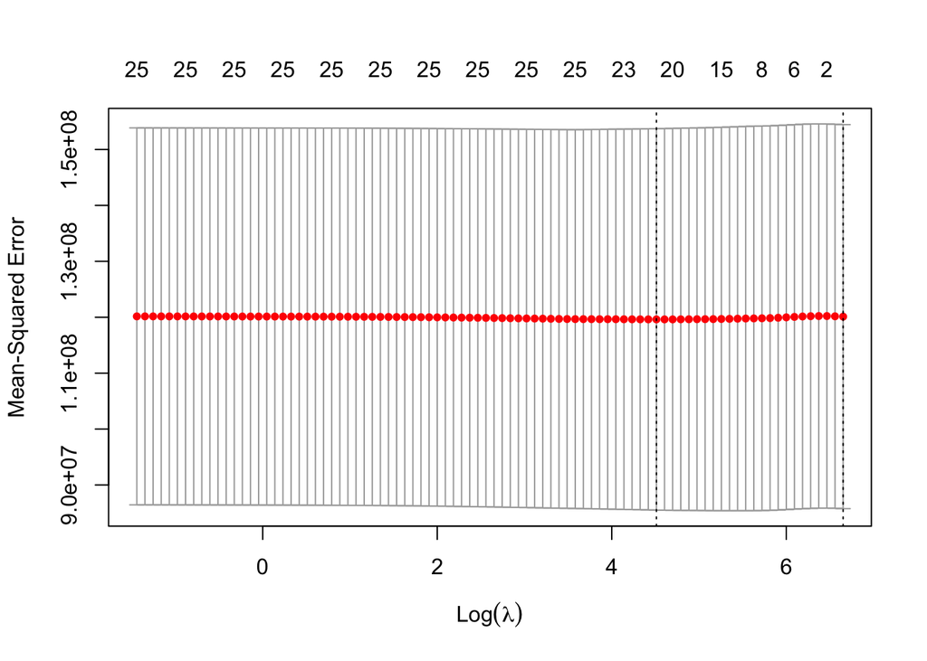

```r
plot(l_train_cv)
```

```r
lasso_1se <- glmnet(x_train, y_train, lambda = l_train_cv$lambda.1se)
coef(lasso_1se)
```

```
26 x 1 sparse Matrix of class "dgCMatrix"
                                             s0
(Intercept)                        4.885095e+03
selfMadeTRUE                       .
categoryConstruction & Engineering .
categoryDiversified                .
categoryEnergy                     .
categoryFashion & Retail           1.033421e-12
categoryFinance & Investments      .
categoryFood & Beverage            .
categoryGambling & Casinos         .
categoryHealthcare                 .
categoryLogistics                  .
categoryManufacturing              .
categoryMedia & Entertainment      .
categoryMetals & Mining            .
categoryReal Estate                .
categoryService                    .
categorySports                     .
categoryTechnology                 .
categoryTelecom                    .
age                                .
genderM                            .
cpi_country                        .
gdp_country                        .
life_expectancy_country            .
total_tax_rate_country             .
population_country                 .
```

```r
lasso_min <- glmnet(x_train, y_train, lambda = l_train_cv$lambda.min)

coef(lasso_min)
```

```
26 x 1 sparse Matrix of class "dgCMatrix"
                                              s0
(Intercept)                         9.195878e+03
selfMadeTRUE                       -6.209341e+02
categoryConstruction & Engineering -1.402630e+03
categoryDiversified                 .
categoryEnergy                      .
categoryFashion & Retail            1.745153e+03
categoryFinance & Investments      -8.261533e+02
categoryFood & Beverage            -6.432208e+02
categoryGambling & Casinos          .
categoryHealthcare                 -1.310609e+03
categoryLogistics                   .
categoryManufacturing              -1.170939e+03
categoryMedia & Entertainment       .
categoryMetals & Mining             9.897152e+02
categoryReal Estate                -1.545856e+03
categoryService                    -1.370728e+03
categorySports                     -1.707656e+03
categoryTechnology                  8.581103e+02
categoryTelecom                     1.602448e+03
age                                 4.394373e+01
genderM                             2.876144e+02
cpi_country                        -7.258245e+00
gdp_country                         7.817462e-11
life_expectancy_country            -8.324093e+01
total_tax_rate_country              1.253715e+01
population_country                 -1.498324e-06
```

```r
yHat <- predict(lasso_min, newx = x_test, s = "lambda.min")
pmse_lmin <- mean((yHat - y_test)^2)
pmse_lmin
```

```
[1] 80324130
```

```r
lasso_min$df
```

```
[1] 20
```

```r
Hat <- predict(lasso_1se, newx = x_test, s = "lambda.1se")
pmse_l1se <- mean((yHat - y_test)^2)
pmse_l1se
```

```
[1] 80324130
```

```r
lasso_1se$df
```

```
[1] 1
```

### Ridge Regression

```r
# Using cross validation results to select lambda
set.seed(123)
r_train_cv <- cv.glmnet(x_train, y_train, alpha = 0 )
r_train_cv
```

```
Call:  cv.glmnet(x = x_train, y = y_train, alpha = 0)

Measure: Mean-Squared Error

    Lambda Index   Measure       SE Nonzero
min   6732    52 119302533 34129548      25
1se 774062     1 120037443 34334508      25
```

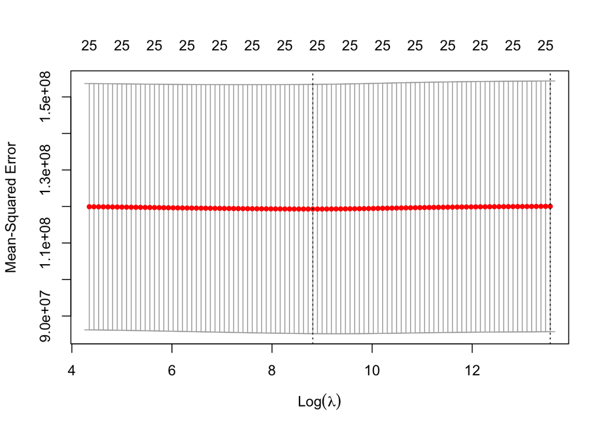

```r
plot(r_train_cv)
```

```r
ridge_min <- glmnet(x_train, y_train, alpha = 0, lambda = r_train_cv$lambda.min)
yHat <- predict(ridge_min, newx = x_test, s = "lambda.min")
pmse_r <-  mean((yHat - y_test)^2)
pmse_r
```

```
[1] 79739204
```

```r
ridge_min$df
```

```
[1] 25
```

### Cross-validation

```r
cleaned_df <-
  Classbill |>
  mutate(selfMade = ifelse(selfMade, 'yes', 'no')) |>
  mutate(selfMade = as.factor(selfMade))
```

```r
library(stats)
library(caret)

set.seed(123)

predictor_cols <- c('selfMade', 'age', 'cpi_country', 'gdp_country', 'life_expectancy_country', 'total_tax_rate_country')

ctrl <- trainControl(method = "cv",
                     number = 10)

lm_model_cv <- train(finalWorth ~ .,
                     data = Classbill[, c('finalWorth', predictor_cols)],
                     method = "lm",
                     trControl = ctrl)

# View cross-validation results
print(lm_model_cv)
```

```
Linear Regression

2407 samples
   6 predictor

No pre-processing
Resampling: Cross-Validated (10 fold)
Summary of sample sizes: 2167, 2165, 2166, 2167, 2166, 2168, ...
Resampling results:

  RMSE      Rsquared    MAE
  9669.946  0.00736524  3963.567

Tuning parameter 'intercept' was held constant at a value of TRUE
```

```r
lm_df <-
  Classbill |>
  select(-rank, -selfMade, -category)
summary(lm(finalWorth ~ ., data = lm_df))
```

```
Call:
lm(formula = finalWorth ~ ., data = lm_df)

Residuals:
   Min     1Q Median     3Q    Max
 -5989  -3153  -2032   -312 205437

Coefficients:
                          Estimate Std. Error t value Pr(>|t|)
(Intercept)              1.988e+04  9.960e+03   1.996 0.046030 *
age                      4.182e+01  1.611e+01   2.595 0.009515 **
genderM                 -1.159e+02  6.460e+02  -0.179 0.857658
cpi_country             -2.376e+01  1.426e+01  -1.667 0.095651 .
gdp_country              7.129e-11  2.771e-11   2.572 0.010157 *
life_expectancy_country -2.024e+02  1.073e+02  -1.886 0.059365 .
total_tax_rate_country   3.251e+01  2.425e+01   1.341 0.180077
population_country      -2.267e-06  6.717e-07  -3.375 0.000749 ***
---
Signif. codes:  0 '***' 0.001 '**' 0.01 '*' 0.05 '.' 0.1 ' ' 1

Residual standard error: 10170 on 2399 degrees of freedom
Multiple R-squared:  0.012, Adjusted R-squared:  0.009112
F-statistic: 4.161 on 7 and 2399 DF,  p-value: 0.0001459
```

```r
x <- as.matrix(Classbill[, predictor_cols])
y <- Classbill$finalWorth

folds <- createFolds(y, k = 10, list = TRUE, returnTrain = FALSE)

lasso_cv <- cv.glmnet(x, y, alpha = 1, nfolds = 10, foldid = folds$Fold)

mse_values <- lasso_cv$cvm

# Display the MSE values for Lasso regression
print("Cross-validated RMSE for Lasso regression:")
```

```
[1] "Cross-validated RMSE for Lasso regression:"
```

```r
print(sqrt(min(lasso_cv$cvm)))
```

```
[1] 10183.7
```

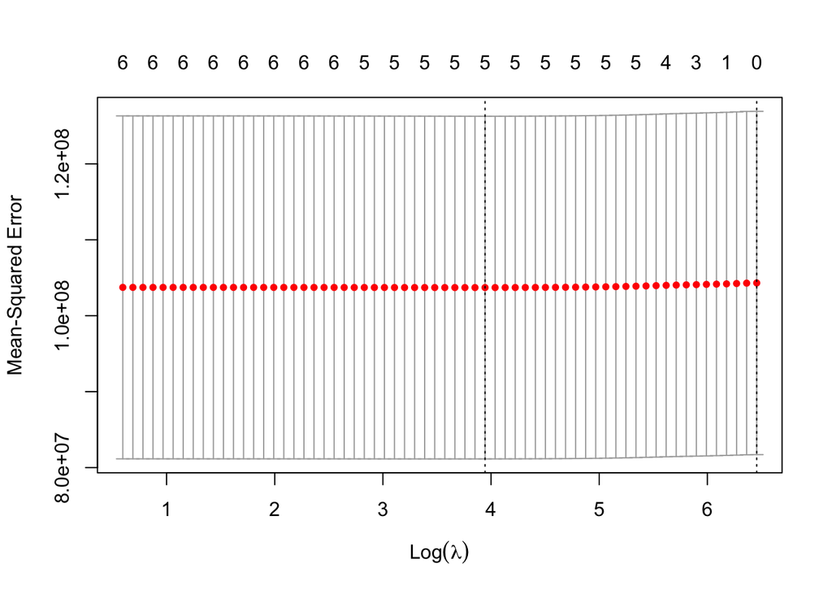

```r
plot(lasso_cv)
```

```r
# predictor_cols <- c('age', 'cpi_country', 'gdp_country', 'life_expectancy_country', 'total_tax_rate_country')

# Prepare data
x <- as.matrix(Classbill[, predictor_cols])
y <- Classbill$finalWorth

# Perform Ridge regression with cross-validation using cv.glmnet
ridge_cv <- cv.glmnet(x, y, alpha = 0, lambda = seq(0.001, 1, length = 100), nfolds = 10)  # Update lambda values and nfolds as needed

# Get the lambda value that minimizes cross-validated error
best_lambda <- ridge_cv$lambda.min

# Predict using the best model
predicted_values <- predict(ridge_cv, newx = x, s = best_lambda)

# Calculate RMSE
rmse <- sqrt(mean((y - predicted_values)^2))

# Display the RMSE for Ridge regression
print("Root Mean Squared Error (RMSE) for Ridge regression:")
```

```
[1] "Root Mean Squared Error (RMSE) for Ridge regression:"
```

```r
print(rmse)
```

```
[1] 10165.26
```